# 7.3 The Critical Value Approach to Hypothesis Testing

## Goals

1. Test one sample means using the critical value approach.

## Idea

- We learned about critical values when we discussed confidence intervals.
- We can use these values in a hypothesis test.
- We will compare these values to a value based on the data, called a **test statistic**.

## Idea

- The null is our “default assumption”.
- If the null is true, how likely are we to observe a sample that looks like the one we have?
- If our sample is very inconsistent with the null hypothesis, we should reject the null hypothesis.

## Test statistics

Test statistics are similar to z- and t-scores: \[\text{test statistic} = \frac{\text{point estimate}-\text{null value}}{\text{standard error}}.\]

- **Large Sample Setting**: \(\mu\) is target parameter, \(n \ge 30\)

\[z = \frac{\bar{x}-\mu_0}{s/\sqrt{n}}\]

- **Small Sample Setting**: \(\mu\) is target parameter, \(n < 30\)

\[t = \frac{\bar{x}-\mu_0}{s/\sqrt{n}}\]

## Test statistics

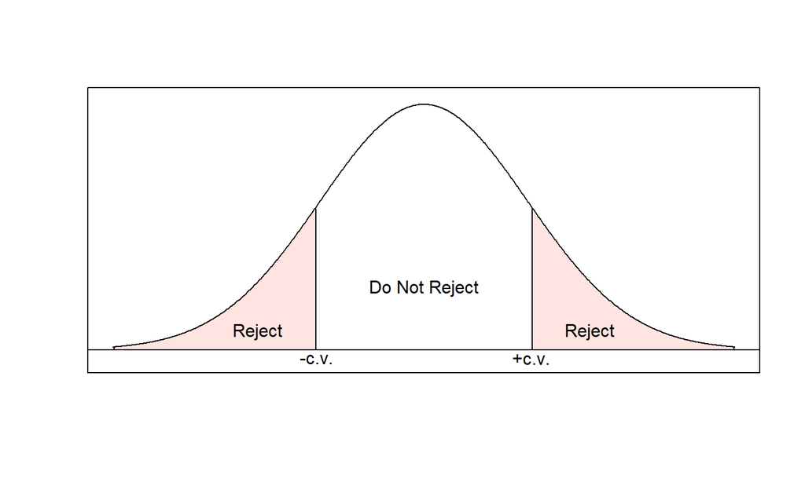

- Values for the test statistic that cause us to reject \(H_0\) are the **rejection region**.
- The remaining values are the **nonrejection region**.
- The value that separates these is the critical value!

## Steps

1. State the null and alternative hypotheses.
2. Determine the significance level \(\alpha\). Check assumptions (decide which setting to use).
3. Compute the value of the test statistic.
4. Determine the critical values.
5. If the test statistic is in the rejection region, reject the null hypothesis. Otherwise, do not reject.
6. Interpret results.

## Example

Researchers took a random sample of 20 green sea turtle nests and counted the number of eggs in each. They found a mean of 107.3 eggs with standard deviation 13.7.

At the 0.1 level of significance, test if the mean number of eggs in green sea turtle clutches is 120.

## Checkpoint

Is the average mercury level in dolphin muscles different from \(2.5\mu g/g\)? Use the critical value approach to test at the 0.05 level of significance. A random sample of \(19\) dolphins resulted in a mean of \(4.4 \mu g/g\) and a standard deviation of \(2.3 \mu g/g\).